# Data cleaning before modelling

# Description

In my previous analysis (Exploratory Data Analysis), I averaged the resistance components across 5 blocks and plotted them. However, I did not know if blocks have effects on the distribution or not. Therefore, in this part of analysis I wanted to see if blocks have significant effects on the variation of the resistance components.

## Objectives

1. Checking the block effects using mixed-effects model
2. Cleaning the dataset from block effects

```r
load(file = "prelim_step2.RData")  # RData prepared from prelim analysis step 2
```

```r
library(ggplot2)  # To map the experimental design
library(hrbrthemes)
library(breedR)  # To model the source of phenotypic variation
```

# Observing block effects using mixed-effects model

I used mixed-effects model to analyze the effects of block and individuals to the variance of the resistance components. Mixed-effects model is a regular model used in animal and plant breeding. There are two parts in the mixed-effects model:

- Fixed part: The factor/variable whose effect is directly affecting the variance of the response variable and whose effect that we would like to test the hypothesis with. In a simple term, I would say this is “a direct variable that affects our test”
- Random part: The factors/variables whose effects are indirectly affecting the variance of response variable and whose effects that we would not consider to test our hypothesis. In a simple term, I would say this is “an indirect or background variable that can affect the variance of our response variable”

In this section, I wanted to adjust the values of my resistance components. In a simple word, I wanted to **eliminate block effects from the values of my resistance components**.

- To do that, I used the resistance components as the response variables.
- I fitted the resistance components to the fixed part of the model so that the model could find the average of the values of the resistance components in the form of an intercept.
- I fitted the genotype and block as random effects because I considered them as the background effects that affect the variance in my resistance components.

To check the significant effects of the individuals I did the following:

- Made a null model where neither the individuals nor the blocks were fitted to the fixed part (the procedures above are the procedures to make a null model)
- Made a model where individuals were fitted to the fixed part (genotype_fit)
- Used chi-square test of the log likelihood between the null model and genotype_fit
- If the test return a value below 0.05, it means that individuals have a significant effect on the variance in the resistance components
- If the test return a value above 0.05, it means that individuals do not have a significant effect.

To check the significant effects of the blocks, I will do the following:

- A null model
- A model where blocks were fitted to the fixed part (block_fit)
- Used chi-square test of the log likelihood between the null model and block_fit
- If the test return a value below 0.05, it means that blocks have a significant effect on the variance in the resistance components
- If the test return a value above 0.05, it means that blocks do not have a significant effect.

```r
# strain_list <- strain_list <- list(s09AX27_clean, s93JE3_clean, sP72_clean)
# List: strain_list, 1 = 09AX27, 2 = 93JE3, 3 = P72
# strain_list is available in prelim analysis step 2, already saved as .RData

# I will run the model in a loop

# First, creating an empty list for each of the resistance components

LP_mix <- list()  # For latent period

UN_mix <- list() # For uredinia number

US_mix <- list() # For uredinia size

# Running a loop for the mixed-effects model through the length of strain_list

for (i in 1:length(strain_list)) {  # For i in 1:3 (because there are 3 pathogens)
  LP_mix[[i]] <- remlf90(fixed = Laten_24.02.15_gp ~ 1,  # Mixmod for latent period
                         random = ~ Genotype + Block,
                         data = strain_list[[i]], # For pathogen 1, then 2, then 3
                         method = "ai")
  UN_mix[[i]] <- remlf90(fixed = total_NbSS ~ 1,  # Mixmod for uredinia number
                         random = ~ Genotype + Block,
                         data = strain_list[[i]],
                         method = "ai")
  US_mix[[i]] <- remlf90(fixed = Taill_05.08.20_gp ~ 1, # Mixmod for uredinia size
                         random = ~ Genotype + Block,
                         data = strain_list[[i]],
                         method = "ai")
}

summary(LP_mix[[1]])  # LP mixed model for pathogen 09AX27 (coded 1 in the strain_list)
```

```
## Formula: Laten_24.02.15_gp ~ 0 + Intercept + Genotype + Block
##    Data: strain_list[[i]]
##   AIC  BIC logLik
##  2338 2352  -1166
##
## Parameters of special components:
##
##
## Variance components:
##          Estimated variances    S.E.
## Genotype             0.41226 0.07720
## Block                0.04908 0.04031
## Residual             1.04160 0.06471
##
## Fixed effects:
##            value   s.e.
## Intercept 10.583 0.1186
```

For simplicity, I will stick to latent period for individuals infected by 09AX27.

For this resistance component, the model gives and intercept of 10.583. In this case, the intercept is the average latent period across genotypes and blocks.

```r
genot_var = LP_mix[[1]]$var[[1]] / (LP_mix[[1]]$var[[1]] + LP_mix[[1]]$var[[2]] +
                                      LP_mix[[1]]$var[[3]])
genot_var*100
```

```
## [1] 27.43022
```

The model also calculates the estimated variance from genotypes and blocks. Here, it shows that genotypes (i.e. the genes of poplar individuals) contribute to 27.4% of latent period variance. Meanwhile, blocks….

```r
block_var = LP_mix[[1]]$var[[2]] / (LP_mix[[1]]$var[[1]] + LP_mix[[1]]$var[[2]] +
                                      LP_mix[[1]]$var[[3]])

block_var*100
```

```
## [1] 3.265664
```

While blocks contribute to 3.3% of latent period variance. However, I don’t know if this is a significant amount of variance to say blocks do not have a significant effect on latent period. So, now I want to check the significant effects by comparing the log-likelihood of null model and the model where genotypes or blocks are in the fixed effects.

### Checking the effects of individuals

```r
genot_fit_LP <- remlf90(fixed = Laten_24.02.15_gp ~ Genotype,
                        random =  ~ Block,
                        data = strain_list[[1]],  # dataset for pathogen 09AX27
                        method = "ai")

# Function to check the significance of individuals and blocks

sig.fun = function(random, non_random, n_test){
  stat = 2*(random - non_random)

  sig = 1 - pchisq(stat, n_test)

  return(sig)
}

random_LP_09 = LP_mix[[1]]$fit$`-2logL` # Getting the log-likelihood from mixed model LP infected with pathogen 09AX27, genotype not in the fixed part

nonrand_LP_09 = genot_fit_LP$fit$`-2logL` # Getting the log-likelihood from mixed model LP infected with pathogen 09AX27, genotype in the fixed part

# Checking the significance of individuals
sig.fun(random = random_LP_09, non_random = nonrand_LP_09, n_test = 153)
```

```
## [1] 0
```

Result: individuals have significant effects on the variance in latent period when they were infected with pathogen 09AX27.

What about the block effects?

### Checking the effects of blocks

```r
block_fit_LP = remlf90(fixed = Laten_24.02.15_gp ~ Block, # fitted = blocks
                       random =  ~ Genotype,
                       data = strain_list[[1]], # LP for individuals infected with 09AX27
                       method = "ai")
```

```
## Using default initial variances given by default_initial_variance()
## See ?breedR.getOption.
```

```r
summary(block_fit_LP)
```

```
## Formula: Laten_24.02.15_gp ~ 0 + Intercept + Block + Genotype
##    Data: strain_list[[1]]
##   AIC  BIC logLik
##  2333 2342  -1165
##
## Parameters of special components:
##
##
## Variance components:
##          Estimated variances    S.E.
## Genotype               0.412 0.07716
## Residual               1.042 0.06472
##
## Fixed effects:
##                               value   s.e.
## Intercept                 10.569169 0.1009
## Block.B4est_1_Bloc_1-28x3  0.154522 0.1240
## Block.B4est_1_Bloc_2_28x3 -0.378840 0.1244
## Block.B4est_1_Bloc_3_28x3  0.245692 0.1257
## Block.B4est_1_Bloc_4_28x3  0.049524 0.1223
## Block.B4est_1_Bloc_5_28x3  0.000000 0.0000
```

```r
# random_LP_09
nonrand2_LP_09 = block_fit_LP$fit$`-2logL` # Getting the log-likelihood from mixed model LP infected with pathogen 09AX27, block in the fixed part

# Checking the significance of blocks
sig.fun(random = random_LP_09, non_random = nonrand2_LP_09, n_test = 4)
```

```
## [1] 0.1767528
```

Turned out blocks do not have a significant effects on the variance in latent period for the individuals infected with pathogen 09AX27.

This is a good indicator for experimental trial. It is expected that individuals should have significant effects on the variance of the resistance components. Moreover, the further analysis is to detect the extent of genetics effects to the resistance components. So, the result makes sense. Furthermore, an experimental design should not introduce a systematic effect to the resistance components. Systematic effects can be from blocks or sample arrangement in the experimental design. It introduces bias to the analysis. So, the ideal result from a good experimental design is non-significant effects from blocks, like how it is shown in the result in this analysis.

# Adjusting the resistance components from block effects

Even if the blocks do not have significant effects on the resistance components, it is still good to remove them to clean my data. The cleaned data will be used for the Genome-Wide Association Study later on.

```r
# Functions for adjustment

# Getting the plot coordinates
fun.coord <- function(X, Y){
  paste(X, Y, sep = "-")  # Using functions: X = dataset$X, Y = dataset$Y
}

# Models: LP_mix (list of 3), UN_mix, US_mix
# LP_mix[[1]] = s09AX27, [[2]] = s93JE3, [[3]] sP72

# Getting the intercept from the model
intercept <- function(mix){  # mix being the name of model
    mix$fixed$Intercept[[1]][1, "value"]  # Example, mix = LP_mix[[1]]
}


# Getting the variance associated to each individual
BLUP.genot <- function(mix, x){  # x being the name of a data frame object
  merge(x, data.frame("Genotype" = rownames(mix$ranef$Genotype[[1]]),
                      "BLUP_Genotype" = mix$ranef$Genotype[[1]]$value),
        by = "Genotype")
}

# Getting the variance associated to each block
BLUP.block <- function(mix, x){
  merge(x, data.frame("Block" = rownames(mix$ranef$Block[[1]]),
                      "BLUP¨.block" = mix$ranef$Block[[1]]$value),
        by = "Block")
}

# Getting the residual variance
BLUP.resid <- function(data, clean, mix){  # clean and data being the name of data frame object
  merge(data, data.frame("coord" = fun.coord(clean$X, clean$Y),
                      "BLUP_resid" = residuals(mix)),
        by = "coord")
}

# Getting the adjusted value
adj <- function(x){  # x being the name of data frame object
  x$intercept + x$BLUP_Genotype + x$BLUP_resid
}
```

## Adjusting latent period

```r
# Creating a list of dataframe to store the results
adj_LP <- list(s09AX27_clean[, -c(6:15)],
               s93JE3_clean[, -c(6:15)],
               sP72_clean[, -c(6:15)])

for (x in 1:length(adj_LP)){
  adj_LP[[x]]$coord <- fun.coord(X = adj_LP[[x]]$X, Y = adj_LP[[x]]$Y)  # adding coordinates to data frame x

  adj_LP[[x]]$intercept <- intercept(mix = LP_mix[[x]])  # adding intercept extracted from mixmodel

  adj_LP[[x]] <- BLUP.genot(mix = LP_mix[[x]], x = adj_LP[[x]])  # adding BLUP estimates extracted from mixmodel

  adj_LP[[x]] <- BLUP.block(mix = LP_mix[[x]], x= adj_LP[[x]])

  adj_LP[[x]] <- BLUP.resid(data = adj_LP[[x]], clean = adj_LP[[x]],  # adding residuals extracted from mixmodel
                             mix = LP_mix[[x]])

  adj_LP[[x]]$adj_LP <- adj(x = adj_LP[[x]])  # adjusting LP by removing block estimates
}
```

Here is the snapshot of the adjusted (i.e. cleaned) latent period dataset for individuals infected by pathogen 09AX27

```r
head(adj_LP[[1]], n = 5)
```

```
##   coord               Block Genotype Strain X  Y intercept BLUP_Genotype
## 1  1-13 B4est_1_Bloc_1-28x3     N-35 09AX27 1 13  10.58336   -0.12180945
## 2  1-14 B4est_1_Bloc_1-28x3    SN-16 09AX27 1 14  10.58336    0.07748278
## 3  1-16 B4est_1_Bloc_1-28x3    1-A09 09AX27 1 16  10.58336    0.44075654
## 4  1-17 B4est_1_Bloc_1-28x3   NOH-28 09AX27 1 17  10.58336    0.87465168
## 5  1-18 B4est_1_Bloc_1-28x3     N-61 09AX27 1 18  10.58336   -0.18824019
##   BLUP..block  BLUP_resid    adj_LP
## 1   0.1212395 -0.90064238  9.560911
## 2   0.1212395 -0.01636240 10.644483
## 3   0.1212395  0.05006835 11.074188
## 4   0.1212395 -0.64568501 10.812330
## 5   0.1212395  0.21791463 10.613038
```

Other individuals infected by pathogen 93JE3 and P72 have the same kind of dataset.

## Adjusting uredinia number

```r
adj_UN <- list(s09AX27_clean[, -c(6:15)],
               s93JE3_clean[, -c(6:15)],
               sP72_clean[, -c(6:15)])

for (x in 1:length(adj_UN)){
  adj_UN[[x]]$coord <- fun.coord(adj_UN[[x]]$X, adj_UN[[x]]$Y)

  adj_UN[[x]]$intercept <- intercept(mix = UN_mix[[x]])

  adj_UN[[x]] <- BLUP.genot(UN_mix[[x]], adj_UN[[x]])

  adj_UN[[x]] <- BLUP.block(UN_mix[[x]], adj_UN[[x]])

  adj_UN[[x]] <- BLUP.resid(data = adj_UN[[x]], clean = adj_UN[[x]],
                            mix = UN_mix[[x]])

  adj_UN[[x]]$adj_UN <- adj(adj_UN[[x]])
}
```

Here is the snapshot of the adjusted (i.e. cleaned) uredinia number dataset for individuals infected by pathogen 09AX27

```r
head(adj_UN[[1]], n = 5)
```

```
##   coord               Block Genotype Strain X  Y intercept BLUP_Genotype
## 1  1-13 B4est_1_Bloc_1-28x3     N-35 09AX27 1 13  7.036516     1.4123318
## 2  1-14 B4est_1_Bloc_1-28x3    SN-16 09AX27 1 14  7.036516    -0.2114908
## 3  1-16 B4est_1_Bloc_1-28x3    1-A09 09AX27 1 16  7.036516    -2.2173441
## 4  1-17 B4est_1_Bloc_1-28x3   NOH-28 09AX27 1 17  7.036516     0.2879847
## 5  1-18 B4est_1_Bloc_1-28x3     N-61 09AX27 1 18  7.036516     1.7141078
##   BLUP..block BLUP_resid   adj_UN
## 1   0.9632557  -1.801781 6.647067
## 2   0.9632557  -2.872338 3.952688
## 3   0.9632557  -3.407668 1.411504
## 4   0.9632557  -1.204031 6.120470
## 5   0.9632557   1.138366 9.888991
```

## Adjusting uredinia size

```r
adj_US <- list(s09AX27_clean[, -c(6:15)],
               s93JE3_clean[, -c(6:15)],
               sP72_clean[, -c(6:15)])

for (x in 1:length(adj_US)){
  adj_US[[x]]$coord <- fun.coord(adj_US[[x]]$X, adj_US[[x]]$Y)

  adj_US[[x]]$intercept <- intercept(mix = US_mix[[x]])

  adj_US[[x]] <- BLUP.genot(US_mix[[x]], adj_US[[x]])

  adj_US[[x]] <- BLUP.block(US_mix[[x]], adj_US[[x]])

  adj_US[[x]] <- BLUP.resid(data = adj_US[[x]], clean = adj_US[[x]],
                            mix = US_mix[[x]])

  adj_US[[x]]$adj_US <- adj(adj_US[[x]])
}
```

Here is the snapshot of the adjusted (i.e. cleaned) uredinia size dataset for individuals infected by pathogen 09AX27

```r
head(adj_US[[1]], n = 5)
```

```
##   coord               Block Genotype Strain X  Y intercept BLUP_Genotype
## 1  1-13 B4est_1_Bloc_1-28x3     N-35 09AX27 1 13  3.518238    0.18207636
## 2  1-14 B4est_1_Bloc_1-28x3    SN-16 09AX27 1 14  3.518238   -0.19393515
## 3  1-16 B4est_1_Bloc_1-28x3    1-A09 09AX27 1 16  3.518238    0.08683741
## 4  1-17 B4est_1_Bloc_1-28x3   NOH-28 09AX27 1 17  3.518238   -1.04307749
## 5  1-18 B4est_1_Bloc_1-28x3     N-61 09AX27 1 18  3.518238   -0.09355806
##   BLUP..block  BLUP_resid   adj_US
## 1 -0.00097167 -0.46649413 3.233821
## 2 -0.00097167  0.10153160 3.425835
## 3 -0.00097167 -0.05672164 3.548354
## 4 -0.00097167  0.89279779 3.367959
## 5 -0.00097167  0.05105103 3.475731
```

## Averaging the adjusted resistance components

```r
# Strain 09AX27
adj_s09AX27 <- s09AX27_clean[, -c(6:15)]

adj_s09AX27$Latence <- adj_LP[[1]]$adj_LP
adj_s09AX27$NbSS <- adj_UN[[1]]$adj_UN
adj_s09AX27$Taille <- adj_US[[1]]$adj_US

# Strain 93JE3
adj_s93JE3 <- s93JE3_clean[, -c(6:15)]

adj_s93JE3$Latence <- adj_LP[[2]]$adj_LP
adj_s93JE3$NbSS <- adj_UN[[2]]$adj_UN
adj_s93JE3$Taille <- adj_US[[2]]$adj_US

# Strain P72
adj_sP72 <- sP72_clean[, -c(6:15)]

adj_sP72$Latence <- adj_LP[[3]]$adj_LP
adj_sP72$NbSS <- adj_UN[[3]]$adj_UN
adj_sP72$Taille <- adj_US[[3]]$adj_US
```

There are still information about blocks. I have to average the values of the resistance components across blocks.

```r
# I have to remove 5 individuals that do not have their corresponding SNPs
# 6-J32, KUH-33, KUH-34, NL-1210, SSC
missing = c("6-J32", "KUH-33", "KUH-34", "NL-1210", "SSC")

# Function to remove the missing individuals
trait.clean = function(data){
  subset(data,!(Genotype %in% missing))
}

trait_list = list(adj_s09AX27, adj_s93JE3, adj_sP72)

# Loop to remove the missing individuals
for (i in 1:length(trait_list)) {
  trait_list[[i]] = trait.clean(trait_list[[i]])
}

# Coercing the block in pathogen
for (i in 1:length(trait_list)) {
  trait_list[[i]]$Block = as.factor(trait_list[[i]]$Block)
}

# Function for averaging the resistance components
mean.all = function(x, Genotype){
  aggregate(x, by = Genotype, mean, na.rm = TRUE)
}

# Lists to store the averaged values
mean_latence = list()
mean_NbSS = list()
mean_taille = list()

# Loop to calculate the averaged values
for (i in 1:length(trait_list)) {
  mean_latence[[i]] = mean.all(trait_list[[i]]$Latence,
                               list(trait_list[[i]]$Genotype))  # Latent period

  mean_NbSS[[i]] = mean.all(trait_list[[i]]$NbSS,
                             list(trait_list[[i]]$Genotype))  # Uredinia number

  mean_taille[[i]] = mean.all(trait_list[[i]]$Taille,
                               list(trait_list[[i]]$Genotype))  # Uredinia size
}

# [[1]] = 09AX27, [[2]] = 93JE3, [[3]] = P72
```

## Extracting the adjusted resistance components

Here is a snapshot for a cleaned dataset of the resistance components. Group = pathogen 09AX27

```r
GWAS_09AX27 = data.frame("Trait" = mean_latence[[1]]$Group.1,
                          "mean_Latence" = mean_latence[[1]]$x,
                          "mean_NbSS" = mean_NbSS[[1]]$x,
                          "mean_Taille" = mean_taille[[1]]$x)
head(GWAS_09AX27, n = 5)
```

```
##   Trait mean_Latence mean_NbSS mean_Taille
## 1 1-A02     10.18248  4.977008    3.796035
## 2 1-A04     11.68678  3.568838    2.569735
## 3 1-A08     11.23342  2.939343    3.010106
## 4 1-A09     11.27439  5.670587    3.230057
## 5 1-A25     10.67487  3.274563    3.207908
```

Group = pathogen 93JE3

```r
GWAS_93JE3 = data.frame("Trait" = mean_latence[[2]]$Group.1,
                         "mean_Latence" = mean_latence[[2]]$x,
                         "mean_NbSS" = mean_NbSS[[2]]$x,
                         "mean_Taille" = mean_taille[[2]]$x)

head(GWAS_93JE3, n = 5)
```

```
##   Trait mean_Latence mean_NbSS mean_Taille
## 1 1-A02     9.626598 11.816564    3.665869
## 2 1-A04     9.912183  5.087618    3.483440
## 3 1-A08     9.602847 14.394689    4.846388
## 4 1-A09    10.045473  7.625770    3.617174
## 5 1-A25     9.449420 15.211705    3.722564
```

Group = pathogen P72

```r
GWAS_P72 <- data.frame("Trait" = mean_latence[[3]]$Group.1,
                       "mean_Latence" = mean_latence[[3]]$x,
                       "mean_NbSS" = mean_NbSS[[3]]$x,
                       "mean_Taille" = mean_taille[[3]]$x)

head(GWAS_P72, n = 5)
```

```
##   Trait mean_Latence mean_NbSS mean_Taille
## 1 1-A02     9.848321  4.215964    2.555992
## 2 1-A04     8.978941 25.942458    3.380224
## 3 1-A08     8.969984 17.026864    4.173381
## 4 1-A09     8.617099 21.112630    3.329459
## 5 1-A25     9.438548 16.447214    3.407456
```

## Plotting the averaged values (Resistance component: Latent period)

And here is the final distribution of latent period. It is in line with the intial insights that I gathered from the raw distribution, but even clearer now.

Here, I see that most individuals infected by 09AX27 started showing the first symptom in much later days than the individuals infected by 93JE3 and P72.

Given that the incubation period was 14 days, the information from latent period gives me the idea that the poplars could resist the population of pathogen 09AX27 much better than the population of pathogen 93JE3 and P72. This situation applied at least at the beginning of the incubation period.

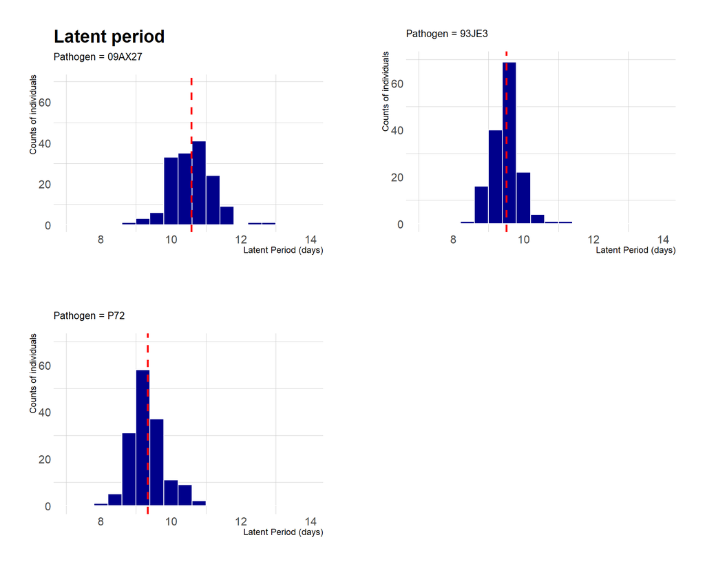

```r
gg = function(data, x, bin){
  ggplot(data, aes(x)) +
    geom_histogram(binwidth = bin, color = "white", fill = "darkblue") +
    geom_vline(aes(xintercept = mean(x)), color = "red",
               linetype = "dashed", size = 1)
}

gg_LP_09AX27 = gg(data = GWAS_09AX27, x = GWAS_09AX27$mean_Latence,
                   bin = 0.4) +
  xlab("Latent Period (days)") +
  ylab("Counts of individuals") +
  scale_x_continuous(limits = c(7,14)) +
  scale_y_continuous(limits = c(0,70)) +
  labs(title = "Latent period", subtitle = "Pathogen = 09AX27") +
  hrbrthemes::theme_ipsum() +
  theme(plot.subtitle = element_text(size = 10),
        panel.grid.major = element_blank())

gg_LP_93JE3 = gg(data = GWAS_93JE3, x = GWAS_93JE3$mean_Latence,
                 bin = 0.4) +
  xlab("Latent Period (days)") +
  ylab("Counts of individuals") +
  scale_x_continuous(limits = c(7,14)) +
  scale_y_continuous(limits = c(0,70)) +
  labs(subtitle = "Pathogen = 93JE3") +
  hrbrthemes::theme_ipsum() +
  theme(plot.subtitle = element_text(size = 10),
        panel.grid.major = element_blank())

gg_LP_P72 = gg(data = GWAS_P72, x = GWAS_P72$mean_Latence,
               bin = 0.4) +
  xlab("Latent Period (days)") +
  ylab("Counts of individuals") +
  scale_x_continuous(limits = c(7,14)) +
  scale_y_continuous(limits = c(0,70)) +
  labs(subtitle = "Pathogen = P72") +
  hrbrthemes::theme_ipsum() +
  theme(plot.subtitle = element_text(size = 10),
        panel.grid.major = element_blank())

# Combining the figures
LP_mean = ggpubr::ggarrange(gg_LP_09AX27, gg_LP_93JE3, gg_LP_P72)

LP_mean
```

## Resistance component: Uredinia number

Individuals had various amounts of spores populating their leaves across different pathogens. However, poplars infected by pathogen P72 were suffering from more spores than the poplars infected by the other two.

In conjunction with latent period, poplars infected by 09AX27 could be populated by the spores only after day 10 (much better than the poplars infected with the other two). Once the spores started populating the leaves, poplars infected by 09AX27 still could retain the population hence low amounts of spore.

Poplars infected by 93JE3 could also resist the population of the spores once they started establishing. Only poplars infected by P72 gave up to the pathogen.

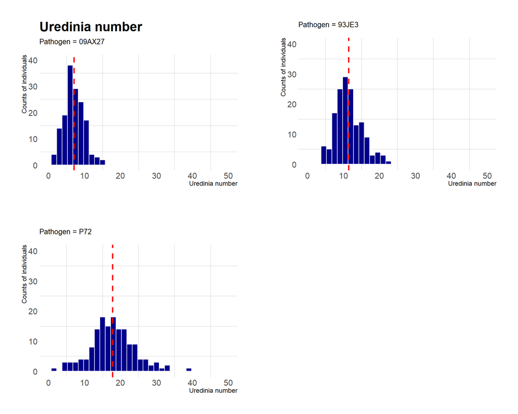

```r
gg_UN_09AX27 = gg(data = GWAS_09AX27, x = GWAS_09AX27$mean_NbSS,
                   bin = 1.5) +
  xlab("Uredinia number") +
  ylab("Counts of individuals") +
  scale_x_continuous(limits = c(0,50)) +
  scale_y_continuous(limits = c(0,40)) +
  labs(title = "Uredinia number", subtitle = "Pathogen = 09AX27") +
  hrbrthemes::theme_ipsum() +
  theme(plot.subtitle = element_text(size = 10),
        panel.grid.major = element_blank())

gg_UN_93JE3 = gg(data = GWAS_93JE3, x = GWAS_93JE3$mean_NbSS,
                 bin = 1.5) +
  xlab("Uredinia number") +
  ylab("Counts of individuals") +
  scale_x_continuous(limits = c(0,50)) +
  scale_y_continuous(limits = c(0,40)) +
  labs(subtitle = "Pathogen = 93JE3") +
  hrbrthemes::theme_ipsum() +
  theme(plot.subtitle = element_text(size = 10),
        panel.grid.major = element_blank())

gg_UN_P72 = gg(data = GWAS_P72, x = GWAS_P72$mean_NbSS,
               bin = 1.5) +
  xlab("Uredinia number") +
  ylab("Counts of individuals") +
  scale_x_continuous(limits = c(0,50)) +
  scale_y_continuous(limits = c(0,40)) +
  labs(subtitle = "Pathogen = P72") +
  hrbrthemes::theme_ipsum() +
  theme(plot.subtitle = element_text(size = 10),
        panel.grid.major = element_blank())

# Combining the figures
UN_mean = ggpubr::ggarrange(gg_UN_09AX27, gg_UN_93JE3, gg_UN_P72)

UN_mean
```

## Resistance component: Uredinia size

In conjuction with latent period and uredinia number.

Poplars infected by 09AX27 could resist the growth of the pathogen in terms of their first spore population, the spread and the size of the spore (in terms of uredinia number and uredinia size, respectively)

Poplars infected by 93JE3 could resist the spread of the pathogen but gave up in resisting the growth of its size (in terms of uredinia size)

Poplars infected by P72 could not resist the spread of the pathogen but put efforts in resisting the growth of its size (in terms of uredinia size)

Bottom line, poplars behaved differently across pathogens. They knew when to fight back and this is a potential to be explored, especially in the search of resistance.

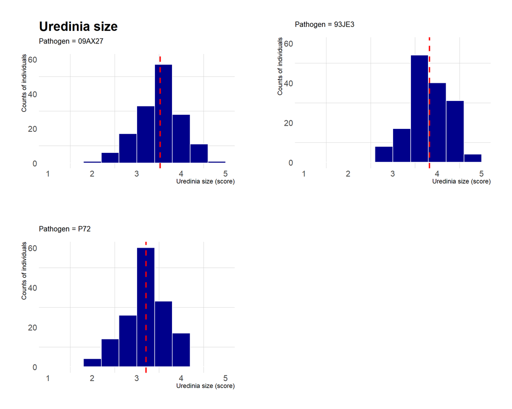

```r
gg_US_09AX27 = gg(data = GWAS_09AX27, x = GWAS_09AX27$mean_Taille,
                   bin = 0.4) +
  xlab("Uredinia size (score)") +
  ylab("Counts of individuals") +
  scale_x_continuous(limits = c(1,5)) +
  scale_y_continuous(limits = c(0,60)) +
  labs(title = "Uredinia size", subtitle = "Pathogen = 09AX27") +
  hrbrthemes::theme_ipsum() +
  theme(plot.subtitle = element_text(size = 10),
        panel.grid.major = element_blank())

gg_US_93JE3 = gg(data = GWAS_93JE3, x = GWAS_93JE3$mean_Taille,
                 bin = 0.4) +
  xlab("Uredinia size (score)") +
  ylab("Counts of individuals") +
  scale_x_continuous(limits = c(1,5)) +
  scale_y_continuous(limits = c(0,60)) +
  labs(subtitle = "Pathogen = 93JE3") +
  hrbrthemes::theme_ipsum() +
  theme(plot.subtitle = element_text(size = 10),
        panel.grid.major = element_blank())

gg_US_P72 = gg(data = GWAS_P72, x = GWAS_P72$mean_Taille,
               bin = 0.4) +
  xlab("Uredinia size (score)") +
  ylab("Counts of individuals") +
  scale_x_continuous(limits = c(1,5)) +
  scale_y_continuous(limits = c(0,60)) +
  labs(subtitle = "Pathogen = P72") +
  hrbrthemes::theme_ipsum() +
  theme(plot.subtitle = element_text(size = 10),
        panel.grid.major = element_blank())

# Combining the plots
US_mean = ggpubr::ggarrange(gg_US_09AX27, gg_US_93JE3, gg_US_P72)

US_mean
```